# Introduction

This is currently Version 1 of the Gaze Tracking System designed to determine which line of text that a reader is currently reading given absolutely no prior knowledge of the page layout or what is being displayed on the screen whatsoever. Currently, the algorithm is able to detect when a reader progresses from one line to the next down the page, beginning from the top, and is able to accurately pinpoint in real time when this change of lines takes place. Given noisy data, the system performs well, and is able to accurately construct the layout of the page in terms of lines of text on the page in real time.

# The System

### Considerations (Version 1)

It is necessary for the system to perform calculations at each time step, which depending on the hardware employed to detect gaze patterns can be fractions of seconds. Thus, decision making processes should be designed with maximum efficiency and minimum complexity in mind. Furthermore, since the system must be tracking the reader's progress throughout the duration of the task, a minimal amount of stored memory is desirable.  
It was first proposed that a Hidden Markov Model (HMM) be used, with each line as its own state, however with careful consideration this approach requires two key pieces of information that may not be available and may limit the capabilities of the system. In order for this approach to be feasible one must know in advance the number of lines per page, and their respective positions on the page. In order to provide the system with real world functionality, the system must be able to learn for itself with no prior knowledge of the environment in which it is working.

### System Overview (Version 1)

A short sequence of events can be used as an abstraction of the system's behavior, which goes as follows:  
**1)** Input data is fed in real time to the system, from the point at which the individual begins reading some line of text. This line is named "Line 1" by the algorithm. At each time step, the x and y coordinates of the reader's gaze are evaluated, and as long as the system remains convinced that the reader is still currently on Line 1 it will remain in a steady state  
**2)** At some point in time the reader will have completed Line 1 and begun a new line. From the moment at which this transition takes place, events which begin to force the system to question whether or not the user is still reading Line 1 begin to occur. Due to the reality of noisy data, a certain threshold must be exceeded in order for the system to conclude that the reader has indeed transitioned from Line 1 to a new line. Currently, an arbitrary value of 60% certainty that the user has begun a new line has been chosen to trigger this event.  
**3)** Following the conclusion that the user is reading a new line, the system will perform a series of operations which adjust parameters such that the new line, named "Line 2" by the algorithm (regardless of whether or not this line is truly the next line of text in the sequence), is the system's new steady state. From here, the process is repeated from 1).  
In order to achieve this desired behaviour, a HMM is employed along with a handful of smaller processes which parse the data prior to being fed to the HMM. I'll explain the details of the system along with its code.

# Code (Version 1)

```python
# imports:
import numpy as np
from pomegranate import * # for HMM stuff
import pandas as pd
import matplotlib.pyplot as plt
from IPython.display import HTML
pd.set_option('display.max_rows', 2500)
pd.set_option('display.max_columns', 2500)
pd.set_option('display.width', 1000)
%matplotlib inline
dat = np.genfromtxt('Coords35_tested_good.csv', delimiter=",")
```

### Sample data

To begin, let's look at some sample data. This data is simulated data produced in Matlab, with a noise level introduced in order to closely mimic human gaze patterns. Since the data was produced in Matlab and sent to the Python program as a .csv file, data could not be fed through the system in real time and thus time step labels were appended as column 2 and a for-loop was implemented to iterate through each data point (see numerical values).  
The sample data can be visualized graphically as follows, using the first 5 lines (out of 25) only in order to preserve space and reduce clutter:

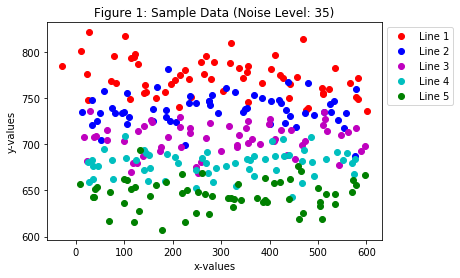

```python
fig1 = plt.figure(1)
plt.plot(dat[:60,0],dat[:60,1], 'ro')
plt.plot(dat[61:120,0],dat[61:120,1], 'bo')
plt.plot(dat[121:180,0],dat[121:180,1], 'mo')
plt.plot(dat[181:240,0],dat[181:240,1], 'co')
plt.plot(dat[241:300,0],dat[241:300,1], 'go')
plt.title('Figure 1: Sample Data (Noise Level: 35)')
plt.xlabel('x-values')
plt.ylabel('y-values')
plt.legend(('Line 1','Line 2','Line 3','Line 4','Line 5'), bbox_to_anchor = (1,1))
plt.show()
```

By looking at the gaze pattern one can see that it resembles a human reader scanning text - beginning at the top-left of the page, and continuing to progress towards the right before advancing to the line below and repeating this cycle until the end of the page is reached, ie: the bottom-right location. Each point on the page is measured with respect to the origin of the page, which is considered here to be the bottom-left corner. As a reader progresses from left to right, we expect to see an increase in the x-values of each gaze point. As a reader progresses down the page from top to bottom, we expect to see a decrease in y-values.  
The first 75 points generated are displayed numerically below.

```python
print('Column 0: x-values\nColumn 1: y-values\nColumn 2: Time step')
print(pd.DataFrame(dat[:75,:]))
```

```
Column 0: x-values
Column 1: y-values
Column 2: Time step
          0       1     2
0    10.140  801.18   0.0
1   -27.484  784.66   1.0
2    26.252  747.77   2.0
3    23.379  775.82   3.0
4   101.500  817.08   4.0
5    27.635  821.59   5.0
6    72.832  768.93   6.0
7    82.567  766.52   7.0
8    78.223  795.32   8.0
9   114.200  794.09   9.0
10  111.580  749.47  10.0
```

[output cut: 64 more lines]

Note the drastic decrease in the x-value of data point 59 compared to data point 60. One would suspect that this is the result of the reader completing one line and continuing to the next, and indeed this is the case (each line consists of 60 data points, a parameter set while generating the sample data to establish a ground truth). Yet another affirmation that the reader is now reading a new line of text is the observation that x-values are now increasing steadily from this new minimum value. However, this metric alone can not accurately predict that a user has begun a new line. For example, points 4 through 8 also exhibit this behavior - in practice it is possible that a reader may need to back-track along the same line of text. For this reason, y-values should also be measured in order to increase confidence when making a new line prediction, however it can be seen in the graphical representation of the data that y-values of neighboring lines often overlap. For this reason, a Hidden Markov Model was constructed in order to give the system additional depth in its decision making process by means of introducing set probabilities of the reader beginning a new line vs. re-reading the same line.

### HMM Parameters - Initial and State Transition Probabilities (Version 1)

Prior to defining some additional program variables, it only makes sense to discuss the initial state probabilities and the state transition probabilities. Below is the code which was used to construct the HMM, using Pomegranate. In Version 1, parameters were first arbitrarily selected then manually tuned until the desired results were achieved.

```python
# First, the emission probabilities for each state:
d1 = DiscreteDistribution({'b1' : 0.7, 'b2' : 0.3})
d2 = DiscreteDistribution({'b1' : 0, 'b2' : 1})

# Attaching the emission probabilities to their proper states
s1 = State(d1, name="s1")
s2 = State(d2, name="s2")

model = HiddenMarkovModel('Gaze Tracker')
model.add_states([s1, s2])

# Pi probabilities are added using "model.start" and the state that we're describing
model.add_transition(model.start, s1, 1)

# State transitions are defined this way
model.add_transition(s1, s1, 0.3)
model.add_transition(s1, s2, 0.7)
model.add_transition(s2, s1, 0.7)
model.add_transition(s2, s2, 0.3)
model.bake()
```

Here, we are defining the three necessary parameters of a discreet HMM: the Pi matrix, which represents the probabilities of starting in any of the defined states at the initial time t = 0, the A matrix which describes the probabilities of transitioning from one hidden state to itself or another in a single time step, and the B matrix (discussed in a later section), which describes the probabilities of observing some particular feature at a moment in time for each state. The states are as follows:  
**State 1:** "Current Line", as long as the observed feature suggests that we are in State 1, no change in the line of text being read will be triggered.  
**State 2:** "New Line", once the observed features begin to consistently suggest that we are in State 2, the system will recognize that the reader has begun a new line of text and will reset and re-allocate variables in order to revert back to State 1, this time considering the new line to be the current line which is being read. (Later versions of the system will hopefully be able to store data from previous lines in order to detect when an individual returns to a previously read line of text).  
The Pi, A, and B matrices are as follows: (due to issues with markdown formatting being lost during HTML conversion, the matrices have been constructed using IPython's HTML function)

```python
HTML("""<div align = "center"><b>Pi</b>:  [1.0, 0]</div>""")
```

**Pi**: [1.0, 0]

Meaning, P(State 1 at t = 0) is 100% and P(State 2 at t = 0) is 0%. In other words, the system will always designate the point at which the reader begins reading as the current line.

```python
HTML("""<div align = "center"><b>State Transition Matrix, A:</b></div> <div align = "center">[ [P(State 1 at time t | State 1 at time t-1) = 0.3, P(State 2 at time t | State 1 at time t-1) = 0.7]</div>
 <div align = "center"> &nbsp;&nbsp;&nbsp;&nbsp;[P(State 1 at time t | State 2 at time t-1) = 0.7, P(State 2 at time t | State 2 at time t-1) = 0.3] ]</div>""")
```

**State Transition Matrix, A:**

[ [P(State 1 at time t | State 1 at time t-1) = 0.3, P(State 2 at time t | State 1 at time t-1) = 0.7]

[P(State 1 at time t | State 2 at time t-1) = 0.7, P(State 2 at time t | State 2 at time t-1) = 0.3] ]

What this means is that the system will be more prone to changing from State 1 to State 2 if it is currently in State 1, given enough supporting evidence that the observed feature suggests that it may be in State 2. The reason for this is as such: let's assume that the system is obtaining noisy data which might suggest that the reader is either re-reading the current line or advancing to a new line. In this event, we would like to decide that the reader is indeed reading a new line rather than continuing to read the same line repeatedly - since that is typically not how humans read text. We would also like the system to be able to quickly leave State 2, the "new line" state, in presence of enough supporting evidence that the reader has begun to read a new line, and count this new line as the new current line. Thus, it has been designed to be more prone to leaving State 2 rather than remaining in State 2. In this version, state transition probabilities have been arbitrarily chosen and adjusted.

### Additional System Variables

```python
obs_seq = np.array(np.zeros((10)), dtype = str)
x_store = np.array(np.zeros((10)))
running_total = 0
count = 1
y_mean = 0
pred = 0
line = 1
xmax = 0
```

### HMM Parameters - Observations and Emission Probabilities

Now that we have discussed some crucial variables, we are able to properly discuss the two possible observations and their emission probabilities. The following are the possible observations:  
**Observation 1 (O1):** In order to describe O1, I'll include the Python code which computes it: "if (x == xmax or x >= xmax-25) and abs(abs(y) - abs(y_mean))<40", then conclude O1. In plain English, if x<sub>t</sub> is the maximum value of the past 10 x-values, or if it falls within a certain negative tolerance of the maximum of the past 10 x-values (chosen arbitrarily at first and manually adjusted to xmax-25), and if y<sub>t</sub> falls within a certain range of the current line's average y-value (chosen arbitrarily at first and manually adjusted to y_mean +/- 40), then conclude O1. This observation serves as the typical feature indicating that the hidden state at this moment in time is State 1, ie: that we have not yet begun to read a new line. Intuitively, this makes sense: if an individual is reading left to right, assuming perfect data and no back-tracking, then the x-values should be consistently increasing. Furthermore, the y-values should remain somewhat close to the average y-value for that particular line of text.  
**Observation 2 (O2):** Once again, in order to describe O2, I'll include the Python code which computes it: "if x < xmax and abs(abs(y) < abs(y_mean))", then conclude O2. That is, if x<sub>t</sub> is less than the maximum value of the past 10 x-values, and if y<sub>t</sub> is less than the current line's average y-value, then conclude O2. This observation serves as the typical feature indicating that the hidden state at this moment in time is State 2, ie: that the reader has finished one line of text and moved on to another. Occasionally, the reader back-tracking in their current line of text will result in O2 - however since O2 must be present in 6/10 of the past ten observations, back-tracking is not a large concern (one can argue that if an individual decides to completely re-read the current line of text, and if each y-value obtained during this time is below the average y-value for the current line, then the system might mistakenly conclude that a new line is being read. This has not yet been the case, although in future versions it may make sense to add an acceptable range to the comparison of y<sub>t</sub> and the average y-value). Intuitively, if the reader has begun a new line of text then the x-values of points obtained during this transition, towards the far left of the page, will be less than at least one of the previous 10 x-values, the maximum of which will ideally be some x-value towards the far right of the page. Additionally, since a new line of text will certainly be located below the previous current line of text if the reader is following a typical reading pattern, then y-values obtained from some new line of data should be somewhat consistently less than the previous current line's average y-value.  
The Emission Probability Matrix, B, is defined as follows:

```python
HTML("""<div align = "center"><b>Emssion Probability Matrix, B:</b></div> <div align = "center">[ [P(O1 at time t | State 1 at time t), b1 = 0.7, P(O2 at time t | State 1 at time t), b2 = 0.3]</div>
 <div align = "center"> &nbsp;&nbsp;&nbsp;&nbsp;[P(O1 at time t | State 2 at time t), b1 = 0.0, P(O2 at time t | State 2 at time t), b2 = 1.0] ]</div>""")
```

**Emssion Probability Matrix, B:**

[ [P(O1 at time t | State 1 at time t), b1 = 0.7, P(O2 at time t | State 1 at time t), b2 = 0.3]

[P(O1 at time t | State 2 at time t), b1 = 0.0, P(O2 at time t | State 2 at time t), b2 = 1.0] ]

So, based on the probabilities outlined in the matrix, we are telling the system that State 1 has a 70% chance of producing Observation 1 and a 30% chance of producing Observation 2. Likewise, State 2 has a 0% chance of producing Observation 1 and a 100% chance of producing Observation 2. These probabilities were first arbitrarily selected and later manually adjusted in order to produce the desired results.

### The "Helper" Algorithm & System Output

While the HMM handles the main decision making process for the system, the ability to reset parameters and prepare data for the HMM's Viterbi Algorithm to receive is given by the "Helper" Algorithm. The man purpose of the Helper Algorithm, as mentioned before, is to reset parameters when necessary and force the system into the "Current Line" state once the reader has begun to read a new line, to manage all important sequence data (such as variables x_new and pred), and to feed each time step's observation sequence to the Viterbi Algorithm for predictions to be made, monitoring each new sequence of predictions and watching for the next point at which to perform a reset. Since there are many different parts to this algorithm, I have included comments within the code in order to explain each piece's function. Also worth noting is that, as you may recall, data was read from a .csv file and as such a for-loop was necessary for iteration rather than real-time sequencing.  
I've added a line in the loop to print the predicted observation sequence as well as the predicted line for each timestep. The output is pretty long, but feel free to inspect it. Keep in mind that every 60 timesteps the data being read switches to a new line. Currently the lag time between when a new line actually begins and when the system recognizes that a new line begins is about five to six timesteps. This can be improved simply by reducing the amount of "State 1's" present in the observation sequence required in order for the system to switch to a new line.

```python
for i in range(len(dat)):

    # At each time step, a new gaze point is read and fed to the algorithm.
    x = dat[i,0]
    y = dat[i,1]

    # Each new y-value is added to the running total and the count is increased, as long as the reader remains on the current line of text
    running_total += y
    y_mean = running_total/count
    count += 1

    # Putting together x_store. Before 10 gaze points of data have been received as input, store each value after the other in x_store. Once more than 10 values have been seen, store each new value in x_store and pop the oldest value out of the array
    if i <= 9:
        x_store[i] = x
    else:
        hold = np.append(x_store, x)
        x_store = hold[1:]

    # Computing xmax
    xmax = np.max(x_store)

    # This is the "reset" portion of the algorithm. If State 1 has been guessed more than 5 times in the past 10 time steps, ie: the state sequence consists of 60% State 1 predictions, then reset the running total, set xmax to be the x-value at this point in time, and reset the observation sequence to observe b1 entirely. In effect, start fresh at this new line.
    if np.sum(pred) > 5:
        xmax = x
        count = 1
        running_total = 0
        # Call this new line "line n+1"
        line += 1
        obs_seq = ['b1','b1','b1','b1','b1','b1','b1','b1','b1','b1']

    # Observations
    if i ==0:
        observation = 'b1'
    if i >= 1:
        if (x == xmax or x >= xmax-25) and abs(abs(y) - abs(y_mean))<40:
            observation = 'b1'
        elif x < xmax and abs(abs(y) < abs(y_mean)):
            observation = 'b2'
        # An old observation that I've left in in case it must be added in the future
        # elif dat[i-1,0] < x and abs(abs(y) < abs(y_mean)):
        #     observation = 'O3'

    # Observation sequence. As with x_store, fill the array with new observations first. Once it is full, pop off the oldest observation and add the newest oservation.
    if i <= 9:
        obs_seq[i] = observation
        x_store[i]
    else:
        hold = np.append(obs_seq, observation)
        obs_seq = hold[1:]

        # Begin predictions once the observation sequence is full. The "predict" function comes built in with Pomegranate and outputs the result of the Viterbi algorithm on the given observation sequence, outputting a new array full of predicted states rather than observations.
        pred = model.predict(obs_seq)
        print(i, pred, "Line:", line)
```

```
10 [0, 0, 0, 0, 0, 1, 0, 0, 0, 0] Line: 1
11 [0, 0, 0, 0, 1, 0, 0, 0, 0, 0] Line: 1
12 [0, 0, 0, 1, 0, 0, 0, 0, 0, 0] Line: 1
13 [0, 0, 1, 0, 0, 0, 0, 0, 0, 0] Line: 1
14 [0, 1, 0, 0, 0, 0, 0, 0, 0, 0] Line: 1
15 [0, 0, 0, 0, 0, 0, 0, 0, 0, 0] Line: 1
16 [0, 0, 0, 0, 0, 0, 0, 0, 0, 0] Line: 1
17 [0, 0, 0, 0, 0, 0, 0, 0, 0, 0] Line: 1
18 [0, 0, 0, 0, 0, 0, 0, 0, 0, 0] Line: 1
19 [0, 0, 0, 0, 0, 0, 0, 0, 0, 0] Line: 1
20 [0, 0, 0, 0, 0, 0, 0, 0, 0, 0] Line: 1
21 [0, 0, 0, 0, 0, 0, 0, 0, 0, 0] Line: 1
22 [0, 0, 0, 0, 0, 0, 0, 0, 0, 0] Line: 1
23 [0, 0, 0, 0, 0, 0, 0, 0, 0, 0] Line: 1
24 [0, 0, 0, 0, 0, 0, 0, 0, 0, 0] Line: 1
```

[output cut: 1475 more lines]